# Feuille d’exercice

Thomas Vroylandt

7 février 2020

# Contexte

On va s’intéresser aux données sur les accidents corporels de circulation mises à disposition par le ministère de l’Intérieur, ici en version 2018 : https://www.data.gouv.fr/fr/datasets/base-de-donnees-accidents-corporels-de-la-circulation/

Les objectifs vont être d’importer ses données, de les jointer avec des données sur la population, par département et commune, et de calculer à différents niveaux des indicateurs d’accidentalité.

On représentera ensuite ces indicateurs sur une ou plusieurs cartes qui seront exportées.

Pour cela, il faut télécharger le dossier https://github.com/tvroylandt/r-cartostat qui contient aussi les slides du cours.

# Packages

- On charge les packages qui vont nous être utiles.

```r
library(tidyverse)
library(here)
library(sf)
library(readxl)
```

# Import des données

Les données sont disponibles dans le dossier `data/dataset/exo`.

Elles se composent :

- D’un fichier sur les accidents en 2018 : `accidents18_exo.csv` ;
- D’un fichier sur la population par département en 2017 : `pop_dep17.csv` ;
- D’un fichier sur la population par commune en 2017 : `pop_com17.xlsx`

## Données accidents

- Importer le fichier sur les accidents dans un objet appelé `df_accidents18`.
- Combien de colonnes comporte-t-il ?
- Combien de lignes ?
- Assurez vous que le type des colonnes est cohérent avec leur contenu.
- Sinon, recodez les colonnes qui sont mal importées.
- Visualisez le jeu de données.

```r
# import
df_accidents18 <-
  read_csv2(
    here("data/dataset/exo/accidents18_exo.csv"),
    col_types = cols(
      id_accident = col_character(),
      mois = col_character(),
      code_dep = col_character(),
      code_com = col_character(),
      luminosite = col_character(),
      agglo = col_character(),
      nb_indemnes = col_double(),
      nb_blesses_hospi = col_double(),
      nb_blesses_legers = col_double(),
      nb_tues = col_double(),
      nb_impliques = col_double()
    )
  )

# dimension
dim(df_accidents18)
```

```
## [1] 57783    11
```

```r
# jeu de données
df_accidents18
```

```
## # A tibble: 57,783 x 11
##    id_accident mois  code_dep code_com luminosite agglo nb_indemnes
##    <chr>       <chr> <chr>    <chr>    <chr>      <chr>       <dbl>
##  1 2018000000~ 1     59       59005    Jour       Hors~           1
##  2 2018000000~ 2     59       59011    Jour       En a~           1
##  3 2018000000~ 3     59       59477    Jour       En a~           1
##  4 2018000000~ 5     59       59052    Jour       En a~           1
##  5 2018000000~ 6     59       59477    Jour       En a~           1
##  6 2018000000~ 9     59       59052    Aube/Crép~ En a~           2
##  7 2018000000~ 9     59       59133    Nuit avec~ En a~           0
##  8 2018000000~ 11    59       59011    Nuit avec~ En a~           1
##  9 2018000000~ 2     59       59550    Jour       Hors~           0
## 10 2018000000~ 3     59       59051    Jour       En a~           1
## # ... with 57,773 more rows, and 4 more variables: nb_blesses_hospi <dbl>,
## #   nb_blesses_legers <dbl>, nb_tues <dbl>, nb_impliques <dbl>
```

## Données population

- Importer les données départementales de population dans un objet `df_pop_dep17`.
- Idem pour les communales dans `df_pop_com17`.

```r
# départements
df_pop_dep17 <- read_csv2(here("data/dataset/exo/pop_dep17.csv"))

df_pop_dep17
```

```
## # A tibble: 100 x 2
##    code_dep pop_tot
##    <chr>      <dbl>
##  1 01        659180
##  2 02        546527
##  3 03        347035
##  4 04        168381
##  5 05        145883
##  6 06       1097496
##  7 07        334688
##  8 08        280032
##  9 09        157210
## 10 10        317118
## # ... with 90 more rows
```

```r
# communes
df_pop_com17 <- read_xlsx(here("data/dataset/exo/pop_com17.xlsx"))

df_pop_com17
```

```
## # A tibble: 34,995 x 2
##    code_com pop_tot
##    <chr>      <dbl>
##  1 01001        794
##  2 01002        249
##  3 01004      14428
##  4 01005       1723
##  5 01006        117
##  6 01007       2841
##  7 01008        767
##  8 01009        339
##  9 01010       1132
## 10 01011        387
## # ... with 34,985 more rows
```

## Bonus - offres

On a construit un jeu de données sur les offres par département : `offres_stmt19.sas7bdat`.

- Importer ce jeu de données.

```r
library(haven)

df_off_dep19 <-
  read_sas(here("data/dataset/exo/offres_stmt19.sas7bdat"))

df_off_dep19
```

```
## # A tibble: 100 x 2
##    DPTETA nb_off
##    <chr>   <dbl>
##  1 73      41954
##  2 28      12814
##  3 60      26753
##  4 52       6105
##  5 89      12723
##  6 01      26490
##  7 77      42081
##  8 84      33083
##  9 27      18903
## 10 45      34033
## # ... with 90 more rows
```

# Calculs départementaux

On va regarder ce que ça donne au niveau des départements.

## Regroupement

- Regrouper les données par département.
- Pour cela on somme les indicateurs.
- Calculer aussi un nombre d’accidents.

```r
df_accidents_dep18 <- df_accidents18 %>%
  group_by(code_dep) %>%
  summarise(nb_accidents = n(),
            nb_indemnes = sum(nb_indemnes),
            nb_blesses_legers = sum(nb_blesses_legers),
            nb_blesses_hospi = sum(nb_blesses_hospi),
            nb_tues = sum(nb_tues),
            nb_impliques = sum(nb_impliques)) %>%
  ungroup()

df_accidents_dep18
```

```
## # A tibble: 101 x 7
##    code_dep nb_accidents nb_indemnes nb_blesses_lege~ nb_blesses_hospi nb_tues
##    <chr>           <int>       <dbl>            <dbl>            <dbl>   <dbl>
##  1 01                454         394              373              275      36
##  2 02                261         242              173              187      31
##  3 03                253         213              158              154      25
##  4 04                204         160              155              131      19
##  5 05                241         242              247               89      19
##  6 06               1156        1066              957              432      57
##  7 07                219         168              145              131      12
##  8 08                124         101               72               87      12
##  9 09                 90          82               54               68      12
## 10 10                327         282              301              115      18
## # ... with 91 more rows, and 1 more variable: nb_impliques <dbl>
```

## Jointure

- Jointer sur les données de population.

```r
df_accidents_dep_pop <- df_accidents_dep18 %>%
  left_join(df_pop_dep17, by = "code_dep")

df_accidents_dep_pop
```

```
## # A tibble: 101 x 8
##    code_dep nb_accidents nb_indemnes nb_blesses_lege~ nb_blesses_hospi nb_tues
##    <chr>           <int>       <dbl>            <dbl>            <dbl>   <dbl>
##  1 01                454         394              373              275      36
##  2 02                261         242              173              187      31
##  3 03                253         213              158              154      25
##  4 04                204         160              155              131      19
##  5 05                241         242              247               89      19
##  6 06               1156        1066              957              432      57
##  7 07                219         168              145              131      12
##  8 08                124         101               72               87      12
##  9 09                 90          82               54               68      12
## 10 10                327         282              301              115      18
## # ... with 91 more rows, and 2 more variables: nb_impliques <dbl>,
## #   pop_tot <dbl>
```

## Calculer des indicateurs

- Calculer le nombre d’accidents pour 10 000 habitants pour chaque département.
- Calculer le nombre de tués pour 10 000 habitants pour chaque département.
- Découper ces deux parts en classes (à choisir manuellement).
- Ne conserver que les variables d’intérêt.
- Enlever les départements à blanc (20 et 976).

```r
df_accidents_dep_pop_r <- df_accidents_dep_pop %>%
  mutate(
    accidents_pop = nb_accidents / pop_tot * 10000,
    tues_pop = nb_tues / pop_tot * 10000,
    accidents_pop_cut = cut(
      accidents_pop,
      include.lowest = TRUE,
      breaks = c(0, 5, 10, 15, 10000)
    ),
    tues_pop_cut = cut(
      tues_pop,
      include.lowest = TRUE,
      breaks = c(0, 0.3, 0.6, 1, 10000),
      labels = c("0,3 et moins", "De 0,3 à 0,6", "De 0,6 à 1", "Plus de 1")
    )
  ) %>%
  select(code_dep,
         nb_accidents,
         accidents_pop,
         accidents_pop_cut,
         tues_pop,
         tues_pop_cut) %>%
  filter(!is.na(tues_pop))

df_accidents_dep_pop_r
```

```
## # A tibble: 100 x 6
##    code_dep nb_accidents accidents_pop accidents_pop_cut tues_pop tues_pop_cut
##    <chr>           <int>         <dbl> <fct>                <dbl> <fct>
##  1 01                454          6.89 (5,10]               0.546 De 0,3 à 0,6
##  2 02                261          4.78 [0,5]                0.567 De 0,3 à 0,6
##  3 03                253          7.29 (5,10]               0.720 De 0,6 à 1
##  4 04                204         12.1  (10,15]              1.13  Plus de 1
##  5 05                241         16.5  (15,1e+04]           1.30  Plus de 1
##  6 06               1156         10.5  (10,15]              0.519 De 0,3 à 0,6
##  7 07                219          6.54 (5,10]               0.359 De 0,3 à 0,6
##  8 08                124          4.43 [0,5]                0.429 De 0,3 à 0,6
##  9 09                 90          5.72 (5,10]               0.763 De 0,6 à 1
## 10 10                327         10.3  (10,15]              0.568 De 0,3 à 0,6
## # ... with 90 more rows
```

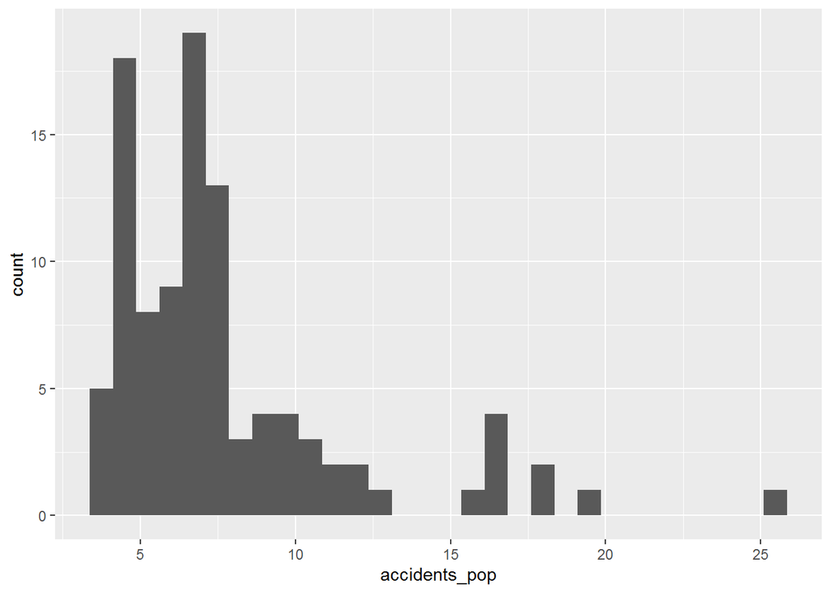

```r
# pour choisir les classes
ggplot(df_accidents_dep_pop_r,
       aes(x = accidents_pop)) +
  geom_histogram()
```

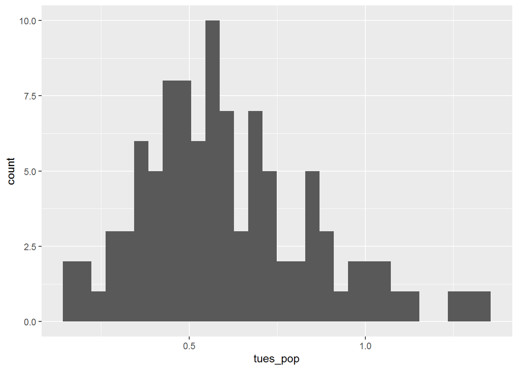

```r
ggplot(df_accidents_dep_pop_r,
       aes(x = tues_pop)) +
  geom_histogram()
```

- Refaire les opérations en conservant la variable `mois`.

```r
df_accidents_dep_pop_mois_r <- df_accidents18 %>%
  group_by(code_dep, mois) %>%
  summarise(
    nb_accidents = n(),
    nb_indemnes = sum(nb_indemnes),
    nb_blesses_legers = sum(nb_blesses_legers),
    nb_blesses_hospi = sum(nb_blesses_hospi),
    nb_tues = sum(nb_tues),
    nb_impliques = sum(nb_impliques)
  ) %>%
  ungroup() %>%
  left_join(df_pop_dep17, by = "code_dep") %>%
  mutate(
    accidents_pop = nb_accidents / pop_tot * 10000,
    tues_pop = nb_tues / pop_tot * 10000,
    accidents_pop_cut = cut(
      accidents_pop,
      include.lowest = TRUE,
      breaks = c(0, 5, 10, 15, 10000)
    ),
    tues_pop_cut = cut(
      tues_pop,
      include.lowest = TRUE,
      breaks = c(0, 0.3, 0.6, 1, 10000),
      labels = c("0,3 et moins", "De 0,3 à 0,6", "De 0,6 à 1", "Plus de 1")
    )
  ) %>%
  select(code_dep,
         mois,
         nb_accidents,
         accidents_pop,
         accidents_pop_cut,
         tues_pop,
         tues_pop_cut) %>%
  filter(!is.na(tues_pop))

df_accidents_dep_pop_mois_r
```

```
## # A tibble: 1,199 x 7
##    code_dep mois  nb_accidents accidents_pop accidents_pop_c~ tues_pop
##    <chr>    <chr>        <int>         <dbl> <fct>               <dbl>
##  1 01       1               32         0.485 [0,5]              0.0455
##  2 01       10              46         0.698 [0,5]              0
##  3 01       11              37         0.561 [0,5]              0.0455
##  4 01       12              36         0.546 [0,5]              0.0303
##  5 01       2               22         0.334 [0,5]              0.0759
##  6 01       3               41         0.622 [0,5]              0.0455
##  7 01       4               33         0.501 [0,5]              0.0152
##  8 01       5               42         0.637 [0,5]              0.0152
##  9 01       6               49         0.743 [0,5]              0.137
## 10 01       7               37         0.561 [0,5]              0.0759
## # ... with 1,189 more rows, and 1 more variable: tues_pop_cut <fct>
```

## Luminosité

- Calculer une part d’accident qui ont lieu le jour, par département.
- Découper cette part en classes selon les quantiles.
- Découper cette part en classes définies manuellement.
- Garder `code_dep` et les variables de pourcentages.

```r
df_accidents_dep_jour18 <- df_accidents18 %>%
  group_by(luminosite, code_dep) %>%
  count() %>%
  group_by(code_dep) %>%
  mutate(perc_jour = n / sum(n) * 100,
         perc_jour = round(perc_jour, 1)) %>%
  filter(luminosite == "Jour") %>%
  ungroup() %>%
  mutate(
    perc_jour_quantile = cut(
      perc_jour,
      breaks = quantile(.$perc_jour),
      include.lowest = TRUE
    ),
    perc_jour_cut = cut(
      perc_jour,
      include.lowest = TRUE,
      breaks = c(0, 70, 75, 80, 100)
    )
  ) %>%
  select(code_dep, starts_with("perc_jour"))

df_accidents_dep_jour18
```

```
## # A tibble: 101 x 4
##    code_dep perc_jour perc_jour_quantile perc_jour_cut
##    <chr>        <dbl> <fct>              <fct>
##  1 01            67.4 (65,67.8]          [0,70]
##  2 02            64.4 [56.3,65]          [0,70]
##  3 03            71.1 (70.6,76.5]        (70,75]
##  4 04            76.5 (70.6,76.5]        (75,80]
##  5 05            76.3 (70.6,76.5]        (75,80]
##  6 06            74.2 (70.6,76.5]        (70,75]
##  7 07            74.4 (70.6,76.5]        (70,75]
##  8 08            61.3 [56.3,65]          [0,70]
##  9 09            72.2 (70.6,76.5]        (70,75]
## 10 10            68.8 (67.8,70.6]        [0,70]
## # ... with 91 more rows
```

## Bonus - Agglomération

- Construire un score de gravité pour chaque accident :
  - Indemne = 0.1 ;
  - Blessés légers = 1 ;
  - Blessés hospitalisés = 2 ;
  - Tués = 5.
- Calculer le score moyen dans et hors agglomération, par département.

```r
df_accidents_score <- df_accidents18 %>%
  mutate(score_acc = 0.1 * nb_indemnes + 1 * nb_blesses_legers + 2 * nb_blesses_hospi + 5 * nb_tues) %>%
  group_by(agglo, code_dep) %>%
  summarise(score_acc_mean = mean(score_acc)) %>%
  ungroup()

df_accidents_score
```

```
## # A tibble: 202 x 3
##    agglo            code_dep score_acc_mean
##    <chr>            <chr>             <dbl>
##  1 En agglomération 01                 2.15
##  2 En agglomération 02                 2.08
##  3 En agglomération 03                 2.13
##  4 En agglomération 04                 2.30
##  5 En agglomération 05                 1.76
##  6 En agglomération 06                 1.82
##  7 En agglomération 07                 1.89
##  8 En agglomération 08                 2.02
##  9 En agglomération 09                 2.48
## 10 En agglomération 10                 1.70
## # ... with 192 more rows
```

- Calculer la différence de score entre dans et hors agglomération, par département (utiliser `pivot_wider` puis `pivot_longer`).

```r
df_accidents_score_diff <- df_accidents_score %>%
  pivot_wider(names_from = agglo,
              values_from = score_acc_mean) %>%
  mutate(diff_score = `Hors agglomération` - `En agglomération`)

df_accidents_score_diff
```

```
## # A tibble: 101 x 4
##    code_dep `En agglomération` `Hors agglomération` diff_score
##    <chr>                 <dbl>                <dbl>      <dbl>
##  1 01                     2.15                 2.77      0.622
##  2 02                     2.08                 3.32      1.23
##  3 03                     2.13                 2.66      0.526
##  4 04                     2.30                 2.69      0.384
##  5 05                     1.76                 2.87      1.11
##  6 06                     1.82                 2.33      0.516
##  7 07                     1.89                 2.38      0.481
##  8 08                     2.02                 3.28      1.26
##  9 09                     2.48                 3.07      0.592
## 10 10                     1.70                 2.68      0.979
## # ... with 91 more rows
```

# Recoupement avec les données spatiales

## Chargement

- Charger le fond de carte départemental qui se trouve dans `data/shp`.

```r
shp_dep <- st_read(here("data/shp/FR_DEP_DOM_IDF.shp"), quiet = TRUE)
```

## Jointure

- On jointe les différentes données avec les fichiers spatiaux :
  - par département ;
  - par département/mois ;
  - pour les accidents de jour ;
  - pour le score agglomération/hors agglomération.

```r
df_accidents_dep_shp <- shp_dep %>%
  inner_join(df_accidents_dep_pop_r, by = "code_dep")

df_accidents_dep_mois_shp <- shp_dep %>%
  inner_join(df_accidents_dep_pop_mois_r, by = "code_dep")

df_accidents_dep_jour_shp <- shp_dep %>%
  inner_join(df_accidents_dep_jour18, by = "code_dep")

df_accidents_dep_agglo_score_shp <- shp_dep %>%
  inner_join(df_accidents_score, by = "code_dep")
```

# Représentation cartographique

## Aplats de couleur

- Représenter la part des accidents qui arrivent le jour en continu.
- Mettre un thème blanc et changer la légende.

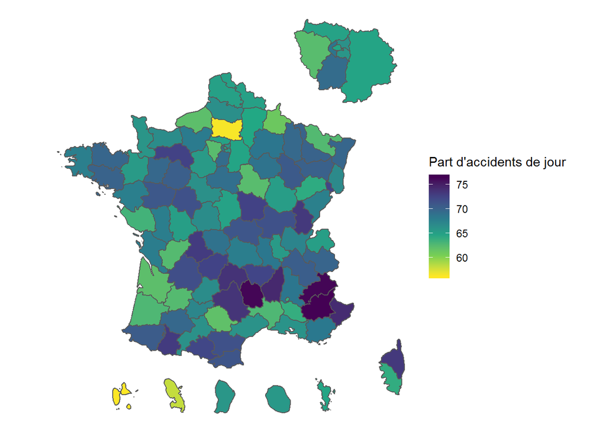

```r
ggplot(data = df_accidents_dep_jour_shp) +
  geom_sf(aes(fill = perc_jour)) +
  scale_fill_viridis_c(name = "Part d'accidents de jour",
                       direction = -1) +
  theme_void()
```

- Faire de même en zoomant sur les Hauts-de-France
- Qu’observe-t-on sur la légende ?

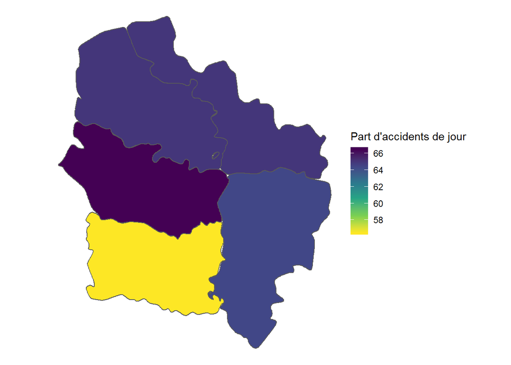

```r
ggplot(data = df_accidents_dep_jour_shp %>%  filter(code_reg == "32")) +
  geom_sf(aes(fill = perc_jour)) +
  scale_fill_viridis_c(name = "Part d'accidents de jour",
                       direction = -1) +
  theme_void()
```

- Faire de même avec la variable découpée en quantile.

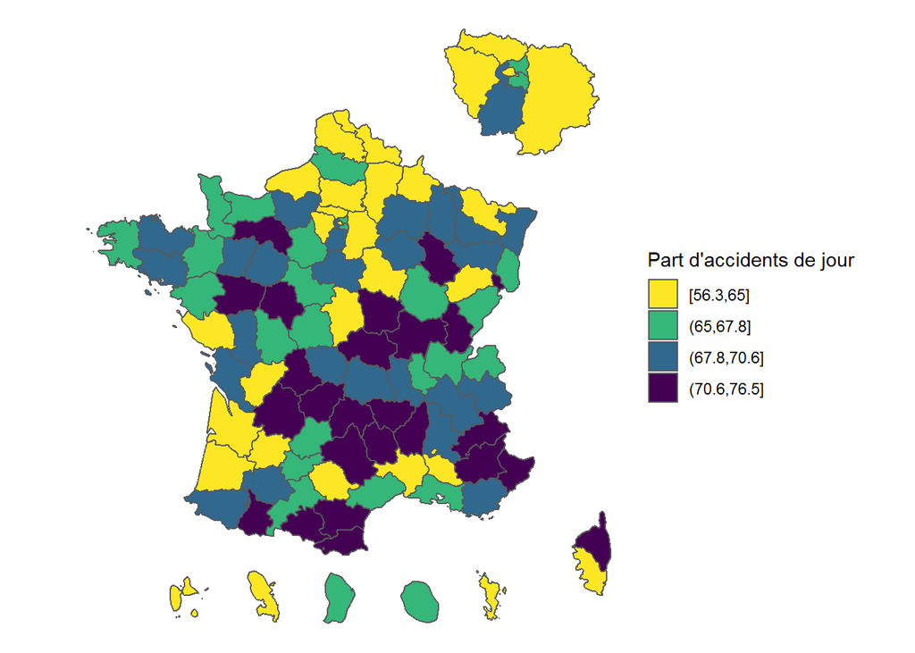

```r
ggplot(data = df_accidents_dep_jour_shp) +
  geom_sf(aes(fill = perc_jour_quantile)) +
  scale_fill_viridis_d(name = "Part d'accidents de jour",
                       direction = -1) +
  theme_void()
```

## Ajouter le texte

- Ajouter la valeur, arrondie à l’unité, sur les départements.
- Si possibles, pour l’Île-de-France, ne le faire que sur le zoom.

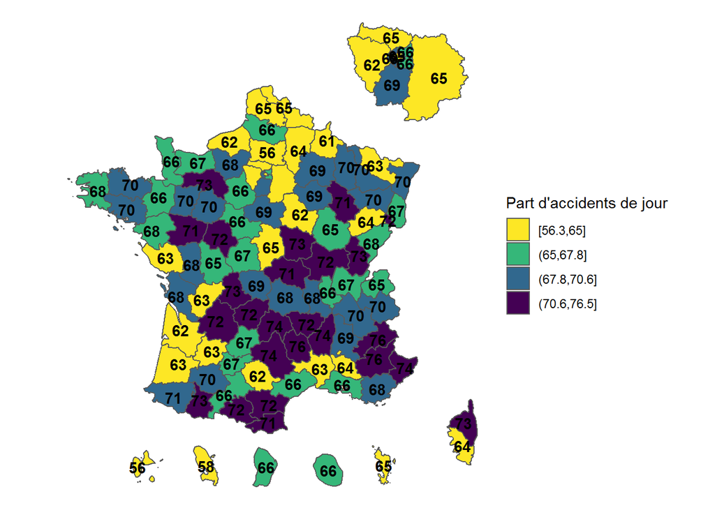

```r
ggplot() +
  geom_sf(data = df_accidents_dep_jour_shp, aes(fill = perc_jour_quantile)) +
  geom_sf_text(
    data = df_accidents_dep_jour_shp %>% filter(zoom_idf == "1" |
                                                  code_reg != "11"),
    aes(label = round(perc_jour, 0)),
    fontface = "bold",
    color = "black"
  ) +
  scale_fill_viridis_d(name = "Part d'accidents de jour",
                       direction = -1) +
  theme_void()
```

## Région

- Charger le fond de carte régions.
- Faire apparaître en plus gros les contours des régions.

```r
shp_reg <- st_read(here("data/shp/FR_REG_DOM.shp"))
```

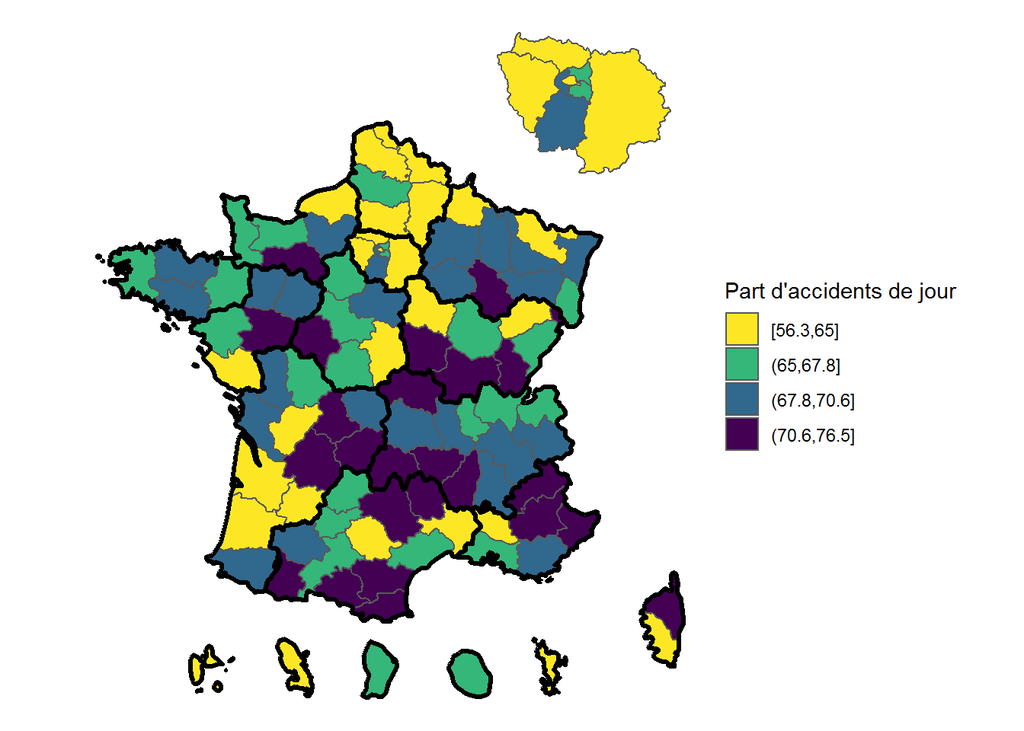

```r
ggplot(data = df_accidents_dep_jour_shp) +
  geom_sf(aes(fill = perc_jour_quantile)) +
  geom_sf(
    data = shp_reg,
    alpha = 0,
    color = "black",
    size = 1.2
  ) +
  scale_fill_viridis_d(name = "Part d'accidents de jour",
                       direction = -1) +
  theme_void()
```

## Cercle proportionnels

- Représenter le nombre d’accidents par des cercles proportionnels.
- En colorer l’intérieur par la part d’accidents par habitant, en continu.

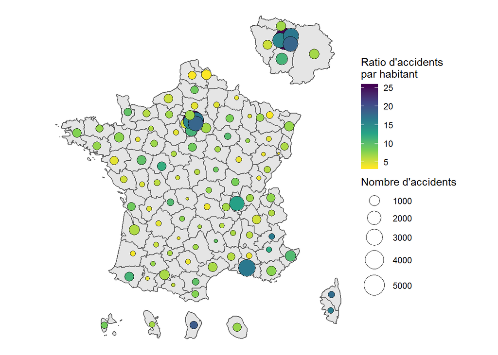

```r
ggplot(df_accidents_dep_shp) +
  geom_sf() +
  stat_sf_coordinates(aes(size = nb_accidents, fill = accidents_pop), shape = 21) +
  scale_fill_viridis_c(name = "Ratio d'accidents \npar habitant", direction = -1) +
  scale_size_continuous(name = "Nombre d'accidents", range = c(1, 10)) +
  theme_void()
```

- En colorer l’intérieur par la part de tués par habitant, en classes.

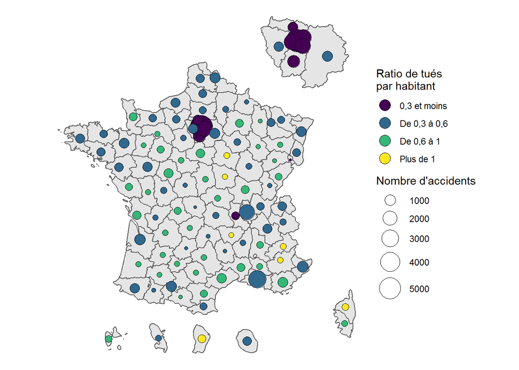

```r
ggplot(df_accidents_dep_shp) +
  geom_sf() +
  stat_sf_coordinates(aes(size = nb_accidents, fill = tues_pop_cut), shape = 21) +
  scale_fill_viridis_d(name = "Ratio de tués \npar habitant", guide = guide_legend(override.aes = list(size =
                                                                                              5))) +
  scale_size_continuous(name = "Nombre d'accidents", range = c(1, 10)) +
  theme_void()
```

## Effet de la saisonnalité

- Faire une carte du nombre d’accidents par habitatn par mois et département.
- On peut facetter avec `facet_wrap` ou `facet_grid`.

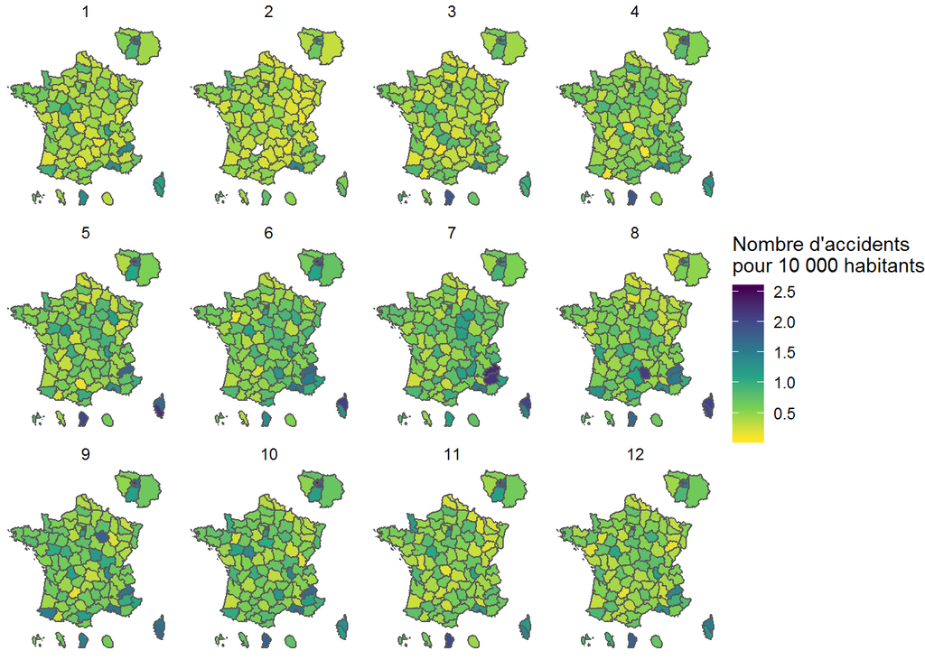

```r
df_accidents_dep_mois_shp %>%
  filter(!is.na(mois)) %>%
  mutate(mois = fct_relevel(mois,
                            "1", "2", "3", "4", "5", "6", "7", "8", "9", "10", "11", "12")) %>%
  ggplot() +
  geom_sf(aes(fill = accidents_pop)) +
  scale_fill_viridis_c(name = "Nombre d'accidents \npour 10 000 habitants",
                       direction = -1) +
  facet_wrap(vars(mois)) +
  theme_void()
```

## Bonus - Agglomération

- Réprésenter le score moyen en et hors agglomération, avec une facette.

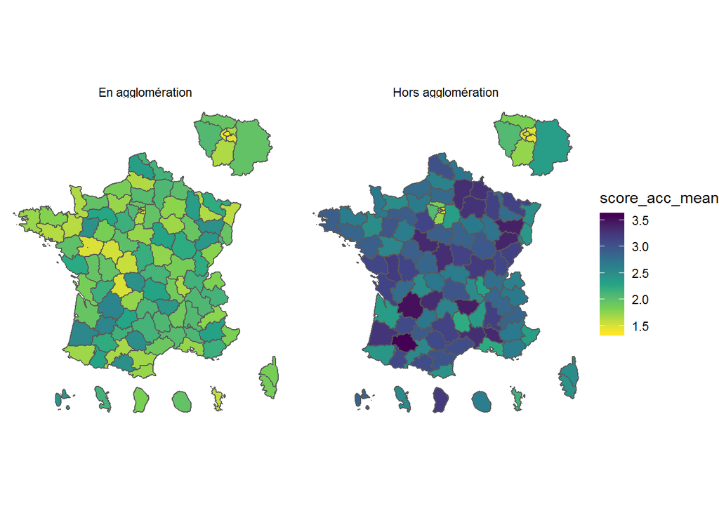

```r
ggplot(df_accidents_dep_agglo_score_shp) +
  geom_sf(aes(fill = score_acc_mean)) +
  scale_fill_viridis_c(direction = -1) +
  facet_wrap(vars(agglo)) +
  theme_void()
```

# Niveau bassin d’emploi

On se penche maintenant sur le niveau bassin d’emploi.

## Regroupement en bassins d’emploi

- Importer la table de passage commune -> bassin d’emploi.

```r
passage_com_bassin <- read_xlsx(here("data/passage/passage_commune_bassin_bmo.xlsx"))
```

- Jointer sur les accidents pour construire le niveau bassin.
- Construire le nombre d’accidents par bassin.

```r
df_accidents_bassin <- df_accidents18 %>%
  inner_join(passage_com_bassin, by = c("code_com" = "code_commune")) %>%
  group_by(code_bassin_bmo) %>%
  count(name = "nb_accidents")
```

- A-t-on des trous ?
- Sur quelles communes ? Regarder d’où ça vient sur le site de l’Insee.

```r
trous_bassin <- df_accidents18 %>%
  anti_join(passage_com_bassin, by = c("code_com" = "code_commune"))

trous_bassin %>%
  group_by(code_com) %>%
  count()
```

```
## # A tibble: 7 x 2
## # Groups:   code_com [7]
##   code_com     n
##   <chr>    <int>
## 1 50439        1
## 2 59248        1
## 3 59540        5
## 4 61377        2
## 5 71260        3
## 6 71511        1
## 7 72318        1
```

- Importer le fond de carte au niveau bassin d’emploi.

```r
shp_bassin <- st_read(here("data/shp/FR_BASSIN_BMO_DOM_IDF_2019.shp"), quiet = TRUE)
```

## Cartes

- Jointer sur le fond de carte.
- Réaliser une carte du nombre d’accidents par bassin d’emploi, en cercles proportionnels.
- Avec en surimpression les régions.

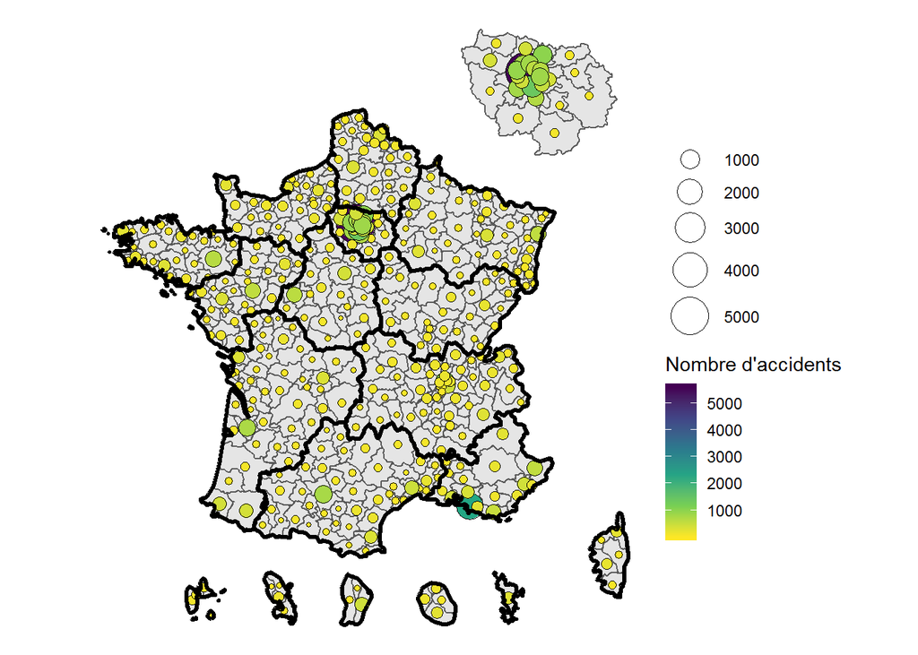

```r
shp_bassin %>%
  inner_join(df_accidents_bassin, by = c("cd_bss_" = "code_bassin_bmo")) %>%
  ggplot() +
  geom_sf() +
  stat_sf_coordinates(aes(size = nb_accidents, fill = nb_accidents), shape = 21) +
  geom_sf(
    data = shp_reg,
    alpha = 0,
    color = "black",
    size = 1.1
  ) +
  scale_fill_viridis_c(name = "Nombre d'accidents",
                       direction = -1) +
  scale_size_continuous(name = "", range = c(1, 10)) +
  theme_void()
```

# Export

```r
ggsave(
  "accidents_bassin.png",
  width = 10,
  height = 8,
  units = "cm"
)
```